# Campus Crime Reporting Before and After Online Sports Betting Policy Changes: Evidence from Six Universities

IBM 5910 — Simulation Week, Group 2

Author

Xueying Luo and Pei Yun Chuang

Published

November 16, 2026

# Abstract (Executive Summary) - Xueying Luo

This report examines campus crime reporting before and after online sports betting launched in Michigan, Ohio, and Florida. We combine 55,218 entries from crime logs at six universities and analyze 40,196 reports dated January 2018 through December 2024. Monthly trends and before-and-after averages measure changes around each state’s online launch. Michigan State’s monthly average fell by 22.7%, and Ohio State’s fell by 1.0% over 24-month comparisons. In Florida’s 12-month comparisons, UCF increased by 29.2%, while Stetson declined by 18.2%. Reports also changed at Pacific and TCU, located in California and Texas, where online sports betting had not launched. Three of the four universities in states that launched online betting recorded lower average monthly counts afterward. These results provide no evidence of a widespread increase in campus crime reports following online sports betting launches.

# Data - Xueying Luo & Pei Yun Chuang

We use 55,218 entries from crime logs supplied for six universities: Michigan State University (17,175 entries), Ohio State University (21,022), Texas Christian University (3,817), the University of the Pacific (3,378), the University of Central Florida (8,848), and Stetson University (978). The original logs span different years, so we focus our analysis on the 40,196 reports dated January 2018 through December 2024. We selected this period to use the same seven-year observation window across all six universities and to cover the online sports betting launches in Michigan, Ohio, and Florida. Although some universities have records from 2025 and 2026, we exclude those years from the analysis to maintain the selected observation period. We retain all 55,218 records in the harmonized dataset and apply the date restriction only in the report analysis.

The combined dataset contains nine fields: reported and occurred dates, reported and occurred times, state, university, standardized crime type, selected online betting launch date, and crime location. We use each entry as one reported incident and count entries by their reported month. This measures how many incidents entered each university’s crime log over time. The focus on reported incidents also makes the six logs usable despite differences in how their original records were organized.

## Cleaning and main measures - Xueying Luo

We cleaned the original logs separately, then combined the six university files. We formatted dates as `YYYY-MM-DD`, times as `HH:MM`, and states as two-letter abbreviations. We also standardized the original offense descriptions into Alcohol offense, Sexual offense, Robbery offense, Burglary offense, Assault offense, and Other. The Other category includes theft, property damage, and descriptions outside the five specified categories. This common classification allows us to compare the distribution of reports across campuses in Figure 3.

We checked repeated records against the available source information and corrected inconsistent offense classifications. We removed documented source duplicates while keeping distinct incidents with matching values in the nine final columns. We also reviewed unusual dates. For example, one UCF entry had an occurrence date of October 28, 2024, even though the incident was reported on October 28, 2023. We retained the report and marked its unverified occurrence date and time as missing. The final dataset contains 816 missing occurrence dates, 1,330 missing reported times, 2,539 missing occurred times, and 62 missing locations. All 55,218 records have a reported date, so these missing fields do not reduce the monthly reporting sample.

We calculate monthly incident totals from the date reported and use the year reported to construct the annual comparison for Pacific and TCU. We focus on online sports betting launch dates rather than the initial availability of retail betting. For our analysis, we use January 22, 2021 for Michigan, January 1, 2023 for Ohio, and November 7, 2023 for Florida. The state-by-state timeline lists Michigan’s earlier retail launch on March 11, 2020, while the Michigan Gaming Control Board’s 2021 Annual Report confirms that internet gaming and sports betting launched on January 22, 2021 (p. 13). Florida’s 2021 gaming compact preceded its November 2023 online launch, so we use the later date. The `gambling legal` column in the corrected CSV contains these selected online launch dates and is empty for California and Texas.

**Policy-date sources:**

Linnehan, Robert. “United States Sports Betting Legal & Regulation Timeline Tracker.” *Sports Betting Dime*, updated October 30, 2026. https://www.sportsbettingdime.com/guides/legal/sports-betting-state-by-state-legal-tracker/.

Michigan Gaming Control Board. *2021 Annual Report*. p. 13. https://www.michigan.gov/mgcb/-/media/Project/Websites/mgcb/About/AnnualReports/2021-MGCB-Annual-Report-Public-Final.pdf.

Our before-and-after comparison uses 24 complete months on each side of the Michigan and Ohio launches. We omit Michigan’s January 2021 launch month and include Ohio’s January 2023 launch month because betting began on January 1. Florida’s November 2023 launch leaves 13 complete post-launch months within our selected 2018–2024 analysis period. We use 12-month comparison windows, from November 2022–October 2023 and December 2023–November 2024, excluding the November 2023 launch month. These windows use the same reported-month outcome but differ in length. They describe local changes in reported incidents around each state’s launch date.

## Cleaning review for Michigan State, Ohio State, and TCU - Pei Yun Chuang

We standardized the Michigan State, Ohio State, and TCU logs into the nine fields required for the combined dataset. These sources contribute 17,175, 21,022, and 3,817 entries, respectively. We checked the university names, state codes, dates, and crime descriptions and reviewed classifications that did not agree with the source descriptions.

A key cleaning issue was identifying repeated incidents. Once the original logs were reduced to nine fields, separate incidents sometimes had identical values. We checked records against the original information before deciding whether to remove them. This helped preserve the report totals used in the monthly series and summary statistics.

## Summary statistics - Pei Yun Chuang

Ohio State recorded the highest average monthly report count among the six universities. From 2018 through 2024, it averaged 226.7 reports per month, with a standard deviation of 86.4 and a range of 29 to 563. Michigan State followed at 121.7 reports per month (standard deviation 66.7), while Stetson averaged 9.7 (standard deviation 6.5). Table 1 reports the mean, standard deviation, minimum, and maximum for all 84 months at each campus. The large differences in counts make it especially useful to examine the direction of change within each university around its launch date, as we do in Figures 1 and 2.

Table 1: Monthly Campus Crime Reports, January 2018–December 2024

| University | Mean | Std. Dev. | Minimum | Maximum | Months |
| --- | --- | --- | --- | --- | --- |
| Michigan State | 121.7 | 66.7 | 24 | 321 | 84 |
| Ohio State | 226.7 | 86.4 | 29 | 563 | 84 |
| Pacific | 23.0 | 10.6 | 7 | 59 | 84 |
| Stetson | 9.7 | 6.5 | 1 | 29 | 84 |
| TCU | 28.4 | 14.8 | 3 | 67 | 84 |
| UCF | 69.1 | 22.2 | 15 | 136 | 84 |

*Table 1 note:* The unit is a university-month. Each university contributes 84 monthly counts from January 2018 through December 2024. Mean, standard deviation, minimum, and maximum summarize the number of entries in each month. Counts are not standardized by campus enrollment.

# Findings/Results - Xueying Luo & Pei Yun Chuang

## Monthly incident trends differ across universities - Xueying Luo

Campus crime reports were already changing well before the online betting launch dates. Figure 1 plots monthly reports from 2018 through 2024 at all six universities, with dashed red lines identifying the launches in Michigan, Ohio, and Florida. Michigan State reported 1,940 incidents in 2019 and 896 in 2020, a decline of 53.8% before its January 2021 online launch. Ohio State also fell from 2,786 reports in 2019 to 2,241 in 2020, while UCF declined from 978 to 687 over those years. The large 2020 shifts occurred during the pandemic and show that campus reporting was moving for reasons beyond the timing of sports betting launches. Figure 1 therefore provides the background needed to interpret the more focused before-and-after averages in Figure 2.

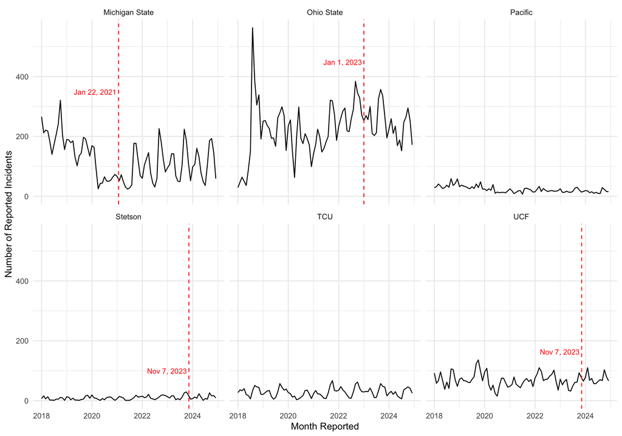

Figure 1: Monthly campus crime reporting changed before and after online betting launches, 2018–2024

*Figure 1 note:* The six panels plot monthly crime-log entries by date reported, January 2018–December 2024, with a shared vertical scale. Dashed red lines identify online launch dates: Michigan, January 22, 2021; Ohio, January 1, 2023; and Florida, November 7, 2023. No line is shown for Pacific (California) or TCU (Texas), where online sports betting had not launched by 2024. Florida had an earlier 2021 compact, followed by interruptions before its 2023 online launch.

## Three of four launch-state campuses recorded lower monthly averages afterward - Xueying Luo

Three of the four universities in states that launched online sports betting recorded fewer monthly reports afterward. Figure 2 provides the main comparison. Michigan State fell from 118.2 to 91.4 reports per month (22.7%) in its 24-month windows. Ohio State remained nearly unchanged, declining from 246.4 to 243.8 (1.0%). In Florida’s 12-month windows, Stetson declined from 14.2 to 11.6 (18.2%), while UCF rose from 57.6 to 74.4 (29.2%). The UCF increase amounts to about 17 additional reports per month; Stetson’s decrease is about three reports per month.

The most notable result is the difference between the two Florida universities. They share the same state launch date and comparison windows, yet their reporting averages moved in opposite directions. Together with the smaller Ohio State change and the Michigan State decline, this gives us no evidence of a common increase in reported campus incidents after online betting launches. The comparisons describe movements in campus reports around each launch; they do not measure a policy effect.

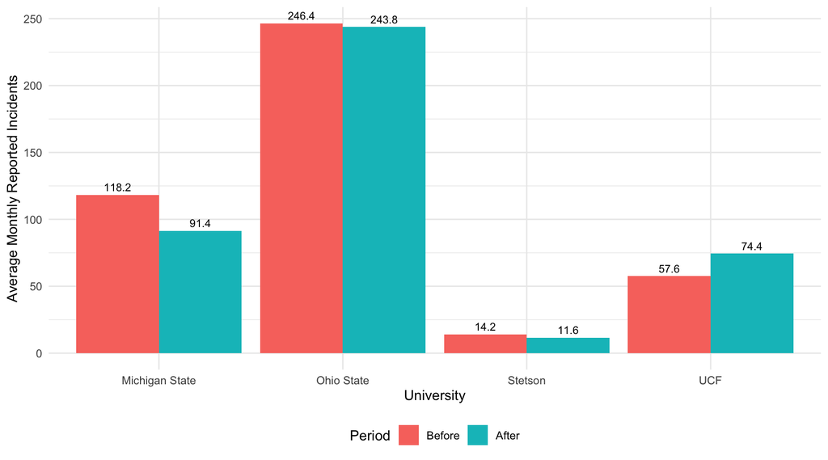

Figure 2: Monthly crime reports fell at three of four campuses after the selected online betting launches

*Figure 2 note:* Bars show the average number of crime-log entries per reported month. Michigan State: January 2019–December 2020 (before, 24 months) and February 2021–January 2023 (after, 24 months). Ohio State: January 2021–December 2022 (before, 24 months) and January 2023–December 2024 (after, 24 months). UCF and Stetson: November 2022–October 2023 (before, 12 months) and December 2023–November 2024 (after, 12 months). November 2023 is excluded as Florida’s launch month. Florida uses shorter windows because its November 2023 launch leaves fewer post-launch months within our selected 2018–2024 analysis period.

## Crime categories differ across campuses - Pei Yun Chuang

The composition of campus reports varies considerably across universities, especially at TCU. Figure 3 compares the percentage assigned to each standardized crime category. Across the 40,196 entries in the analysis sample, 31,703 (78.9%) fall in Other, a group that includes theft and property damage. Other accounts for 88.1% of Stetson reports and 62.8% of TCU reports. At TCU, alcohol offenses make up 24.9% of entries, a substantially larger share than at the other campuses.

These differences matter for the research question because the totals in Figures 1 and 2 combine several types of incidents. A rise in the total number of reports may be concentrated in one category and may not describe the same mix of offenses at another university. Figure 3 identifies this variation in the data, although our before-and-after comparisons still use total monthly reports.

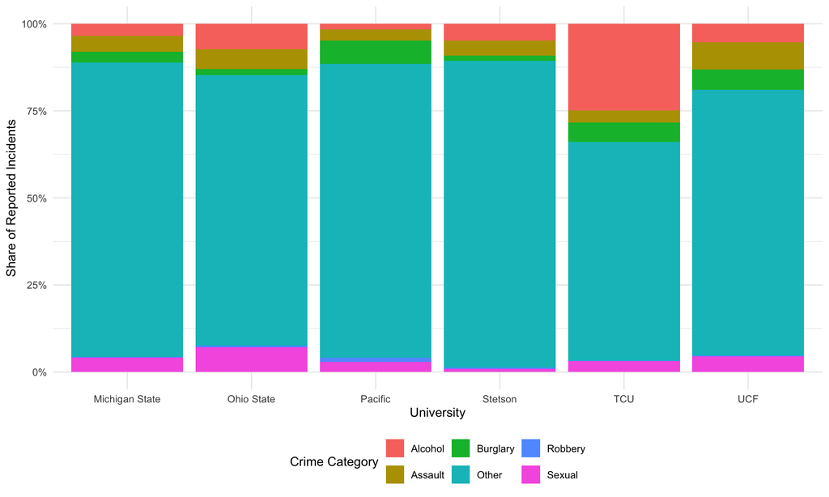

Figure 3: The Other category dominates reports, while TCU has a larger alcohol-offense share, 2018–2024

*Figure 3 note:* Each university’s bar totals 100% of its crime-log entries dated January 2018–December 2024. Segments show the share assigned to Alcohol, Sexual, Robbery, Burglary, Assault, or Other; percentages use that campus’s total as the denominator. Other includes descriptions such as theft and property damage. Category assignments follow our harmonization of the original campus logs.

## Reports also changed at campuses without an online betting launch - Pei Yun Chuang

Reported crime also changed at Pacific and TCU, even though online sports betting had not launched in California or Texas during the study period. Figure 4 shows that Pacific’s annual reports declined from 454 in 2018 to 189 in 2024, a 58.4% decrease. TCU followed a different path: reports fell from 348 in 2019 to 212 in 2020, rebounded to 401 in 2022, and reached 328 in 2024.

These two universities help put the launch-state results in context. Pacific experienced a long decline without an online sports betting launch, while TCU’s reports fell and recovered over the same seven-year period. Therefore, the decreases at Michigan State and Stetson cannot be treated as unique to states with online betting. Figure 4 supports the central conclusion that changes in campus reports were not consistently linked to the launch dates.

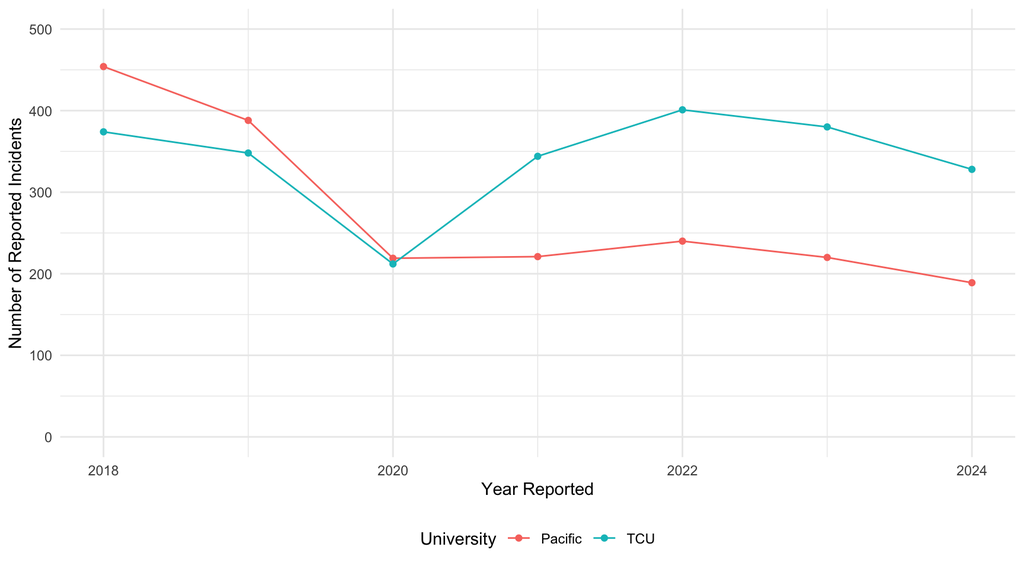

Figure 4: Campus reports changed in California and Texas without online sports betting launches, 2018–2024

*Figure 4 note:* Each point is the annual number of crime-log entries by report year, 2018–2024. Pacific is in California, and TCU is in Texas; neither state launched online sports betting during this period. The lines show annual totals for two comparison campuses with different reporting volumes.

# Conclusion - Pei Yun Chuang

Campus crime reports did not show a general increase after online sports betting launched. The average monthly count fell at Michigan State and Stetson, barely changed at Ohio State, and rose at UCF. Pacific and TCU also experienced sizeable changes in states without online launches. The strongest finding is the lack of a shared pattern: even the two Florida universities moved in opposite directions over the same 12-month comparison periods.

The analysis uses reported incident counts, and the original logs differ across universities. Changes in student populations, campus activity during COVID-19, or reporting procedures may have contributed to the observed movements. Florida’s shorter comparison period also limits comparisons with Michigan and Ohio. A useful next step would be to examine monthly changes by offense category and incorporate enrollment data and campus activity measures. Those additions would help identify which types of reports drive the differences and whether the trends persist after accounting for broader changes across universities.

## Project links

- [GitHub Repository](https://github.com/Sheilaaa0312/Data_Wrangling_Simulation_Week)
- [GitHub Pages](https://sheilaaa0312.github.io/Data_Wrangling_Simulation_Week/Group2_Simulation_Week_Report.html)

# Appendix

## Contribution statement - Xueying Luo

I cleaned and standardized the crime logs for the University of the Pacific, the University of Central Florida, and Stetson University. I also helped combine the six universities into the harmonized dataset and reviewed date formats, crime categories, missing values, and consistency across the files. For the report, I drafted the Executive Summary, the Data overview and main measures, and the first two Results sections. I created Figure 1 to show monthly trends and online betting launch dates and Figure 2 to compare reports before and after the selected milestones. I also helped review the combined report for consistent wording, figures, and interpretation.

## Contribution statement - Pei Yun Chuang

I was responsible for preparing and reviewing the harmonized crime-log data for Michigan State University, Ohio State University, and Texas Christian University. My work included standardizing the fields needed for the combined dataset and reviewing the consistency of the cleaned records. For the final report, I contributed the summary statistics section and table, the discussion of crime categories and Figure 3, the comparison-state analysis and Figure 4, and the conclusion. I also reviewed the limitations of interpreting crime-log counts as campus crime rates or causal effects of sports betting legalization.